# Homework 2 – Decision Tree, Random Forest Classifier, and Optimization

```python
import pandas as pd
from sklearn.model_selection import train_test_split
from sklearn.preprocessing import LabelEncoder
from sklearn.tree import DecisionTreeClassifier
from sklearn.metrics import accuracy_score
from sklearn.tree import plot_tree
import matplotlib.pyplot as plt
from sklearn.metrics import accuracy_score
```

## PART 1:

### Load the dataset and prepare the data

```python
#loading dataset into pandas dataframe
D=pd.read_csv('PlayTennis.csv')
D.head(5)
```

|  | outlook | temp | humidity | windy | play |
| --- | --- | --- | --- | --- | --- |
| 0 | sunny | hot | high | False | no |
| 1 | sunny | hot | high | True | no |
| 2 | overcast | hot | high | False | yes |
| 3 | rainy | mild | high | False | yes |
| 4 | rainy | cool | normal | False | yes |

```python
D.describe().T
```

|  | count | unique | top | freq |
| --- | --- | --- | --- | --- |
| outlook | 14 | 3 | sunny | 5 |
| temp | 14 | 3 | mild | 6 |
| humidity | 14 | 2 | high | 7 |
| windy | 14 | 2 | False | 8 |
| play | 14 | 2 | yes | 9 |

### Split the data into training and testing sets

```python
X = D.drop('play', axis=1)
y = D['play']
```

### b.Convert string data types to numeric using LabelEncoder

```python
le = LabelEncoder()
X = X.apply(le.fit_transform)
```

```python
X_train, X_test, y_train, y_test = train_test_split(X, y, test_size=0.2, random_state=1)
```

### c.Set criterion to “gini”.

```python
dtc = DecisionTreeClassifier(criterion='gini', max_depth=3)
dtc.fit(X_train, y_train)
```

```
DecisionTreeClassifier(max_depth=3)
```

### d. Visualize the Decision Tree:

We can visualize the decision tree using the plot_tree function from the scikit-learn tree package or using the graphviz library. Here I have used plot_tree.

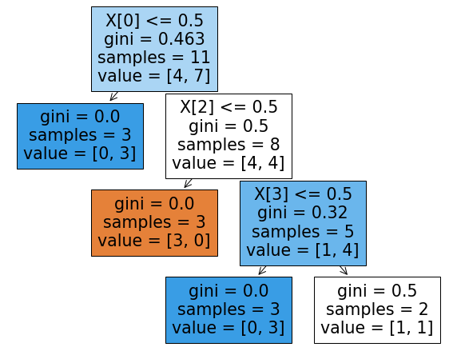

```python
plt.figure(figsize=(10,8))
plot_tree(dtc, filled=True)
plt.show()
```

### Evaluate the Model:

We can evaluate the accuracy of our model by making predictions on the testing set and comparing the predictions to the actual labels.

```python
# Make predictions on the testing set
y_pred1 = dtc.predict(X_train)

# Calculate accuracy score
accuracy = accuracy_score(y_train, y_pred1)
print('Training Accuracy:', accuracy)
```

```
Training Accuracy: 0.9090909090909091
```

```python
# Make predictions on the testing set
y_pred = dtc.predict(X_test)

# Calculate accuracy score
accuracy = accuracy_score(y_test, y_pred)
print('Testing Accuracy:', accuracy)
```

```
Testing Accuracy: 0.6666666666666666
```

### Fitting the model

```python
from sklearn import tree
clf = tree.DecisionTreeClassifier(criterion = 'entropy')
clf = clf.fit(X, y)
```

[output not shown]

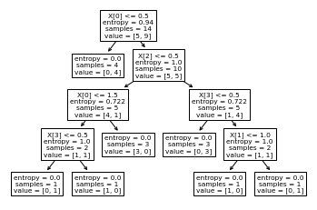

```python
# We can visualize the tree using tree.plot_tree
tree.plot_tree(clf)
```

```python
# The predictions are stored in X_pred
X_pred = clf.predict(X_test)
```

```python
X_pred
```

```
array(['yes', 'no', 'yes'], dtype=object)
```

```python
y_test
```

```
3    yes
7     no
6    yes
Name: play, dtype: object
```

```python
# verifying if the model has predicted it all right.
from sklearn.metrics import confusion_matrix,classification_report
print("Confusion Matrix:\n\n", confusion_matrix(y_test,X_pred))
print("\n\nClassification Report is:\n\n",classification_report(y_test,X_pred))
```

```
Confusion Matrix:

 [[1 0]
 [0 2]]


Classification Report is:

               precision    recall  f1-score   support

          no       1.00      1.00      1.00         1
         yes       1.00      1.00      1.00         2

    accuracy                           1.00         3
   macro avg       1.00      1.00      1.00         3
weighted avg       1.00      1.00      1.00         3
```

# PART 2:

### Using red wine quality dataset and random forest classifier to classify high quality wines and low quality wines.

### Using the pd.cut() function to create the labels

```python
import pandas as pd
# Load the dataset
df = pd.read_csv('winequality-red.csv')
```

```python
df
```

|  | fixed acidity | volatile acidity | citric acid | residual sugar | chlorides | free sulfur dioxide | total sulfur dioxide | density | pH | sulphates | alcohol | quality |
| --- | --- | --- | --- | --- | --- | --- | --- | --- | --- | --- | --- | --- |
| 0 | 7.4 | 0.700 | 0.00 | 1.9 | 0.076 | 11.0 | 34.0 | 0.99780 | 3.51 | 0.56 | 9.4 | 5 |
| 1 | 7.8 | 0.880 | 0.00 | 2.6 | 0.098 | 25.0 | 67.0 | 0.99680 | 3.20 | 0.68 | 9.8 | 5 |
| 2 | 7.8 | 0.760 | 0.04 | 2.3 | 0.092 | 15.0 | 54.0 | 0.99700 | 3.26 | 0.65 | 9.8 | 5 |
| 3 | 11.2 | 0.280 | 0.56 | 1.9 | 0.075 | 17.0 | 60.0 | 0.99800 | 3.16 | 0.58 | 9.8 | 6 |
| 4 | 7.4 | 0.700 | 0.00 | 1.9 | 0.076 | 11.0 | 34.0 | 0.99780 | 3.51 | 0.56 | 9.4 | 5 |
| ... | ... | ... | ... | ... | ... | ... | ... | ... | ... | ... | ... | ... |
| 1594 | 6.2 | 0.600 | 0.08 | 2.0 | 0.090 | 32.0 | 44.0 | 0.99490 | 3.45 | 0.58 | 10.5 | 5 |
| 1595 | 5.9 | 0.550 | 0.10 | 2.2 | 0.062 | 39.0 | 51.0 | 0.99512 | 3.52 | 0.76 | 11.2 | 6 |
| 1596 | 6.3 | 0.510 | 0.13 | 2.3 | 0.076 | 29.0 | 40.0 | 0.99574 | 3.42 | 0.75 | 11.0 | 6 |
| 1597 | 5.9 | 0.645 | 0.12 | 2.0 | 0.075 | 32.0 | 44.0 | 0.99547 | 3.57 | 0.71 | 10.2 | 5 |
| 1598 | 6.0 | 0.310 | 0.47 | 3.6 | 0.067 | 18.0 | 42.0 | 0.99549 | 3.39 | 0.66 | 11.0 | 6 |

1599 rows × 12 columns

### b.Quality has 6 unique numerical values

```python
df['quality'].unique()
```

```
array([5, 6, 7, 4, 8, 3])
```

### Created the three class labels

```python
labels = ['bad','decent','excellent']
df['quality_label'] = pd.cut(df['quality'], bins=3, labels=labels)
```

```python
# Check the result
print(df['quality_label'].value_counts())
```

```
decent       1319
excellent     217
bad            63
Name: quality_label, dtype: int64
```

```python
df['quality_label'].unique()
```

```
['decent', 'excellent', 'bad']
Categories (3, object): ['bad' < 'decent' < 'excellent']
```

### C.To convert the quality labels from string to numeric data, i used sklearn.preprocessing.LabelEncoder class.

```python
from sklearn.preprocessing import LabelEncoder
# Encode the quality labels as numeric values
le = LabelEncoder()
df['quality_label_encoded'] = le.fit_transform(df['quality_label'])
```

```python
# Check the result
print(df['quality_label_encoded'].value_counts())
```

```
1    1319
2     217
0      63
Name: quality_label_encoded, dtype: int64
```

### D.To get a baseline accuracy for comparison, we splited the dataset into training and testing sets, and train a random forest classifier using the default hyperparameters.

```python
from sklearn.model_selection import train_test_split
from sklearn.ensemble import RandomForestClassifier
```

```python
# Split the dataset into training and testing sets
X = df.drop(['quality', 'quality_label', 'quality_label_encoded'], axis=1)
y = df['quality_label_encoded']
X_train, X_test, y_train, y_test = train_test_split(X, y, test_size=0.2, random_state=42)
```

```python
# Train a random forest classifier with default hyperparameters
rfc = RandomForestClassifier(random_state=42)
rfc.fit(X_train, y_train)
```

```
RandomForestClassifier(random_state=42)
```

```python
# Evaluate the performance on the testing set
accuracy = rfc.score(X_test, y_test)
print('Baseline accuracy:', accuracy)
```

```
Baseline accuracy: 0.865625
```

### E. Using the Grid Search algorithm to find the best hyperparameters for the random forest classifier is a good way to improve the performance.

```python
from sklearn.model_selection import GridSearchCV

# Define the hyperparameters to tune
param_grid = {
    'n_estimators': [10,20,100],
    'max_depth': [10, 20, 30],
    'max_features': ['auto', 'sqrt', 'log2']
}
```

```python
# Create a grid search object
grid_search = GridSearchCV(estimator=rfc, param_grid=param_grid, cv=10)
```

```python
# Fit the grid search object to the training data
grid_search.fit(X_train, y_train)
```

```
GridSearchCV(cv=10, estimator=RandomForestClassifier(random_state=42),
             param_grid={'max_depth': [10, 20, 30],
                         'max_features': ['auto', 'sqrt', 'log2'],
                         'n_estimators': [10, 20, 100]})
```

```python
# Print the best hyperparameters and the corresponding accuracy
print('Best hyperparameters:', grid_search.best_params_)
print('Accuracy:', grid_search.best_score_)
```

```
Best hyperparameters: {'max_depth': 30, 'max_features': 'auto', 'n_estimators': 100}
Accuracy: 0.8694574311023622
```

```python
from sklearn.model_selection import RandomizedSearchCV
from scipy.stats import uniform
```

```python
distributions = {'n_estimators': [10,20,100],
    'max_depth': [10, 20, 30],
    'max_features': ['auto', 'sqrt', 'log2']}
```

```python
clf = RandomizedSearchCV(rfc, distributions, cv=5)
grid_search.fit(X_train, y_train)
# Print the best hyperparameters and the corresponding accuracy
print('Best hyperparameters:', grid_search.best_params_)
print('Accuracy:', grid_search.best_score_)
```

[output not shown]